### PACKAGE INSTALLATION

If you are new to R, you may need to install some of the dependencies:

```r
if (!requireNamespace("BiocManager", quietly = TRUE))
install.packages("BiocManager")
BiocManager::install()

library(BiocManager)
BiocManager::install(c("caret", "devtools", "data.table", "dplyr", "furrr", "future", "future.apply",
  "ggplot2", "grDevices", "gridExtra", "igraph", "irlba", "janitor", "Matrix", "methods",
  "plotly", "plyr", "purrr", "randomForest", "rhdf5", "rtracklayer", "scales", "stats", "stringr",
  "tibble", "tidyr", "umap", "utils"))
```

Next, install a few additional dependencies found on Github, including amethyst itself.

```r
devtools::install_github("JinmiaoChenLab/Rphenograph")
devtools::install_github("KrishnaswamyLab/MAGIC/Rmagic")
devtools::install_github("lrylaarsdam/amethyst")
```

Now load libraries into R:

```r
library(amethyst)
library(data.table)
library(ggplot2)
library(dplyr)
library(tibble)
library(tidyr)
library(plyr)
library(future)
library(furrr)
library(purrr)
library(cowplot)
library(pheatmap)
```

### LOADING PRACTICE DATA

First, download the practice data. This vignette comes with site-level CpG methylation information from 50 human banked PBMCs. Download the h5 file and associated metadata with the following commands.

- Note: By default, data will download to the ~/Downloads folder. Change if a different directory is desired.

```r
download.file("https://adeylabopen.s3.us-west-2.amazonaws.com/amethyst/pbmc_vignette.h5", "~/Downloads/pbmc_vignette.h5", method = "curl") # Contains site-level methylation information for each cell
download.file("https://raw.githubusercontent.com/lrylaarsdam/amethyst/main/pbmc_vignette/pbmc_vignette_cellInfo.txt", "~/Downloads/pbmc_vignette_cellInfo.txt") # Summary QC statistics for each cell
download.file("https://raw.githubusercontent.com/lrylaarsdam/amethyst/main/pbmc_vignette/pbmc_vignette.annot", "~/Downloads/pbmc_vignette.annot") # Simulated batch metadata
```

### ASSEMBLING THE AMETHYST OBJECT

Now construct an amethyst object, which stores the path to the h5 file as well as a lot of other information that will be calculated downstream.

```r
obj <- createObject()
```

Next, we need to add metadata about each cell. Useful metadata includes quality control metrics contained in the .cellInfo.txt intermediate output or .annot files, if using the Adey lab Premethyst workflow.

```r
obj <- addCellInfo(obj, file = "~/Downloads/pbmc_vignette_cellInfo.txt")
obj <- addAnnot(obj, file = "~/Downloads/pbmc_vignette.annot", name = "batch")
head(obj@metadata)
```

[output not shown]

While not essential, it can be helpful to filter cells with outlying coverage values right away so downstream functions don’t perform calculations for cells that will not be used. This can easily be done with dplyr logic. First, view the coverage distribution, then filter as necessary.

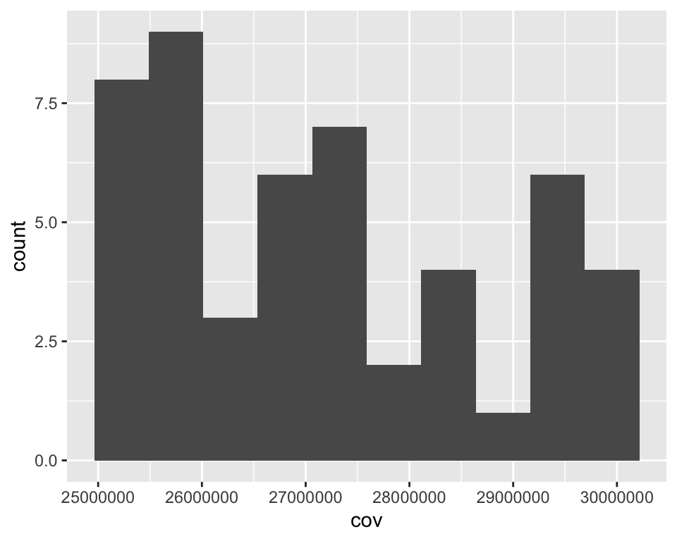

```r
ggplot(obj@metadata, aes(x = cov)) + geom_histogram(bins = 10)
```

```r
obj@metadata <- obj@metadata |> dplyr::filter(cov > 100000 & cov < 40000000)
```

Next, we need to specify the location of the h5 file containing site-level methylation data for each barcode. In this case, every barcode belongs to the same h5 file, but an unlimited number of h5 files can be used in the same object. Row names are barcodes and the “paths” column specifies each path.

```r
obj@h5paths <- data.frame(row.names = rownames(obj@metadata), paths = rep("~/Downloads/pbmc_vignette.h5", length(rownames(obj@metadata))))
head(obj@h5paths)
```

```
##                                                     paths
## ACGCGACGGCACGAGAATCACTGTCATG ~/Downloads/pbmc_vignette.h5
## ACGCGACGGCTATACCGAAGCGCCTATA ~/Downloads/pbmc_vignette.h5
## ACTTCTGCCAACGCTTCGTCAGTACTCC ~/Downloads/pbmc_vignette.h5
## ACTTCTGCCAACGCTTCGTCGATGATCC ~/Downloads/pbmc_vignette.h5
## ACTTCTGCCAAGATAGAGGTCGTCTGCG ~/Downloads/pbmc_vignette.h5
## ACTTCTGCCAATAATCGCGGCTGATGCT ~/Downloads/pbmc_vignette.h5
```

### CLUSTERING

The next step is to cluster cells, which we typically do based on methylation values over fixed genomic windows. An initial indexing helps reduce the computational load by determining the locations corresponding to each chromosome in every h5 file and only calculating across one at a time.

- Note: You may have to copy/paste any code reading the h5 file (e.g., makeWindows) directly into the console instead of running the chunk, if using the .Rmd template

```r
obj@index[["chr_cg"]] <- indexChr(obj, type = "CG", threads = 1)
obj@genomeMatrices[["cg_100k_score"]] <- makeWindows(obj,
                                                     stepsize = 100000,
                                                     type = "CG",
                                                     metric = "score",
                                                     threads = 1,
                                                     index = "chr_cg",
                                                     nmin = 2)
```

You may want to remove windows where many values are NA. The appropriate threshold will highly depend on how big the windows are and how many cells you have. In this case, since the vignette data is high coverage and the genomic windows are large, I am going to filter for at least 90% of the cells have values in that window.

```r
obj@genomeMatrices[["cg_100k_score"]] <- obj@genomeMatrices[["cg_100k_score"]][rowSums(!is.na(obj@genomeMatrices[["cg_100k_score"]])) >= nrow(obj@metadata)*.9, ]
```

Next, perform dimensionality reduction with irlba. If you are unsure how many dimensions to use, the dimEstimate function can estimate the number needed to explain the desired variance threshold. *Note: In this example, the number of requested output dimensions is low because pbmc_vignette.h5 has 50 cells.

```r
dimEstimate(obj, genomeMatrices = c("cg_100k_score"), dims = c(10), threshold = 0.95)
```

```
## cg_100k_score
##             7
```

As suggested, we will reduce the data from obj@genomeMatrices[[“cg_100k_score”]] into seven dimensions using the irlba package, which performs fast truncated singular value decomposition.

```r
set.seed(111)
obj@reductions[["irlba"]] <- runIrlba(obj, genomeMatrices = c("cg_100k_score"), dims = c(7), replaceNA = c(0))
obj@reductions[["irlba_regressed"]] <- regressCovBias(obj, reduction = "irlba") # Optional; helps reduce coverage bias in clustering
```

Now determine cluster membership using the Rphenograph package. *Note: In this example, k_phenograph and neighbors parameters are low because pbmc_vignette.h5 has 50 cells.

```r
set.seed(111)
obj <- runCluster(obj, k_phenograph = 10, reduction = "irlba_regressed") # consider increasing k_phenograph to 50 for larger datasets
```

```
## Run Rphenograph starts:
##   -Input data of 50 rows and 7 columns
##   -k is set to 10
```

```
##   Finding nearest neighbors...DONE ~ 0.001 s
##   Compute jaccard coefficient between nearest-neighbor sets...DONE ~ 0.002 s
##   Build undirected graph from the weighted links...DONE ~ 0.005 s
##   Run louvain clustering on the graph ...DONE ~ 0.003 s
```

```
## Run Rphenograph DONE, totally takes 0.0110000000000099s.
```

```
##   Return a community class
##   -Modularity value: 0.5290332
##   -Number of clusters: 3
```

Umap and tsne are dimensionality reduction techniques frequently used to collapse higher-order information into two or three coordinates for visualization of single-cell data. Either or both methods can be used as input for dimensionality reduction- based visualization functions like dimFeature.

```r
set.seed(111)
obj <- runUmap(obj, neighbors = 5, dist = 0.05, method = "euclidean", reduction = "irlba_regressed")
obj <- runTsne(obj, perplexity = 10, method = "euclidean", theta = 0.2, reduction = "irlba_regressed")
```

### Visualizing the results

First, plot the UMAP or TSNE coordinates of the cells with the color corresponding to cluster membership.

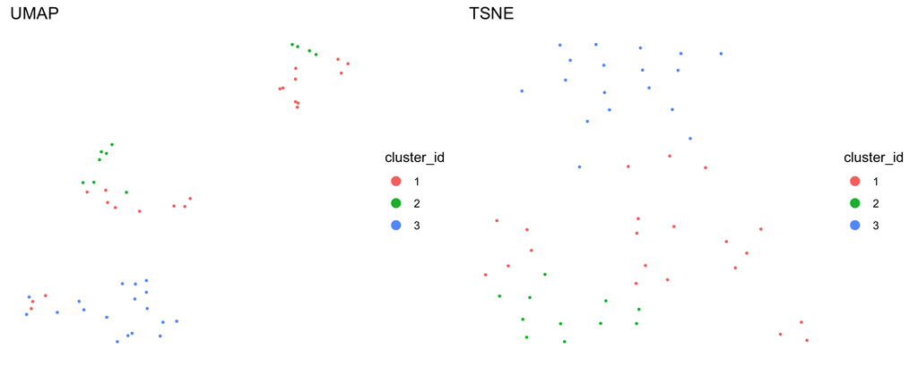

```r
p1 <- dimFeature(obj, colorBy = cluster_id, reduction = "umap") + ggtitle("UMAP")
p2 <- dimFeature(obj, colorBy = cluster_id, reduction = "tsne") + ggtitle("TSNE")
plot_grid(p1, p2)
```

You might find that fixed genomic windows don’t give you good resolution of groups. Any feature set can be used for dimensionality reduction input. The makeWindows function can also calculate methylation levels over a bed file or genes (not recommended unless you are calculating %mCH.) Here is another clustering example using a set of pre-identified PBMC differentially methylated regions (DMRs).

```r
download.file("https://raw.githubusercontent.com/lrylaarsdam/amethyst/main/pbmc_vignette/pbmc_highconfidence_dmrs.bed", "~/Downloads/pbmc_dmr.bed")
obj@genomeMatrices[["pbmc_dmrs"]] <- makeWindows(obj, bed = "~/Downloads/pbmc_dmr.bed", type = "CG", metric = "percent", threads = 1, index = "chr_cg", nmin = 2)
obj@genomeMatrices[["pbmc_dmrs"]] <- obj@genomeMatrices[["pbmc_dmrs"]][rowSums(!is.na(obj@genomeMatrices[["pbmc_dmrs"]])) >= nrow(obj@metadata)*.2, ]
```

Now re-run irlba with the DMR-based windows:

```r
dimEstimate(obj, genomeMatrices = c("pbmc_dmrs"), dims = c(10), threshold = 0.90)
```

```
## pbmc_dmrs
##         8
```

```r
set.seed(111)
obj@reductions[["irlba"]] <- runIrlba(obj, genomeMatrices = c("pbmc_dmrs"), dims = c(8), replaceNA = c(0))
obj@reductions[["irlba_regressed"]] <- regressCovBias(obj, reduction = "irlba")
```

Now re-run clustering and UMAP:

```r
set.seed(111)
obj <- runCluster(obj, k_phenograph = 10, reduction = "irlba_regressed") # consider increasing k_phenograph to 50 for larger datasets
```

```
## Run Rphenograph starts:
##   -Input data of 50 rows and 8 columns
##   -k is set to 10
```

```
##   Finding nearest neighbors...DONE ~ 0 s
##   Compute jaccard coefficient between nearest-neighbor sets...DONE ~ 0.001 s
##   Build undirected graph from the weighted links...DONE ~ 0.001 s
##   Run louvain clustering on the graph ...DONE ~ 0 s
```

```
## Run Rphenograph DONE, totally takes 0.00199999999998113s.
```

```
##   Return a community class
##   -Modularity value: 0.5210422
##   -Number of clusters: 4
```

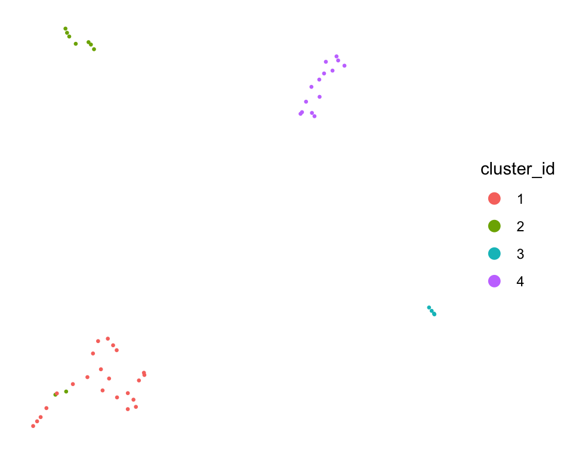

```r
set.seed(111)
obj <- runUmap(obj, neighbors = 5, dist = 0.05, method = "euclidean", reduction = "irlba_regressed")
dimFeature(obj, colorBy = cluster_id, reduction = "umap")
```

In this context, DMRs worked much better than genomic windows for clustering. dimFeature uses ggplot logic, so you can easily modify plots as needed. For example:

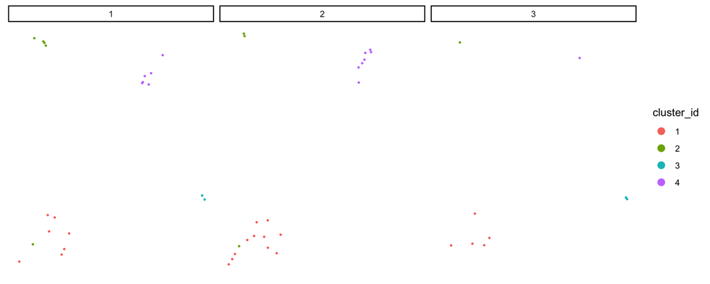

```r
dimFeature(obj, colorBy = cluster_id) + facet_wrap(vars(batch)) # Batch is simulated to illustrate function utility. Any column in the metadata will work.
```

(Optional) If you want to make the umap/tsne plots look nicer, amethyst provides many built-in color palettes:

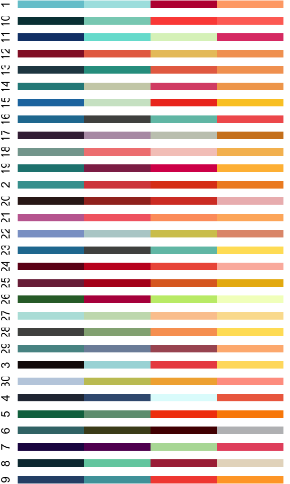

```r
testPalette(output = "swatch", n = length(unique(obj@metadata$cluster_id)))
```

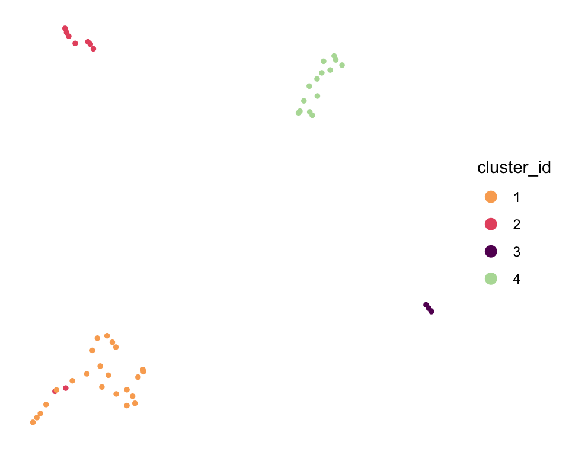

```r
pal <- c("#F9AB60", "#E7576E", "#630661", "#B5DCA5") # makePalette(option = 7, n = 4)
dimFeature(obj, colorBy = cluster_id, colors = pal, pointSize = 1)
```

Show the distribution of cluster membership between samples with sampleComp. Plots can be easily modified with ggplot command logic.

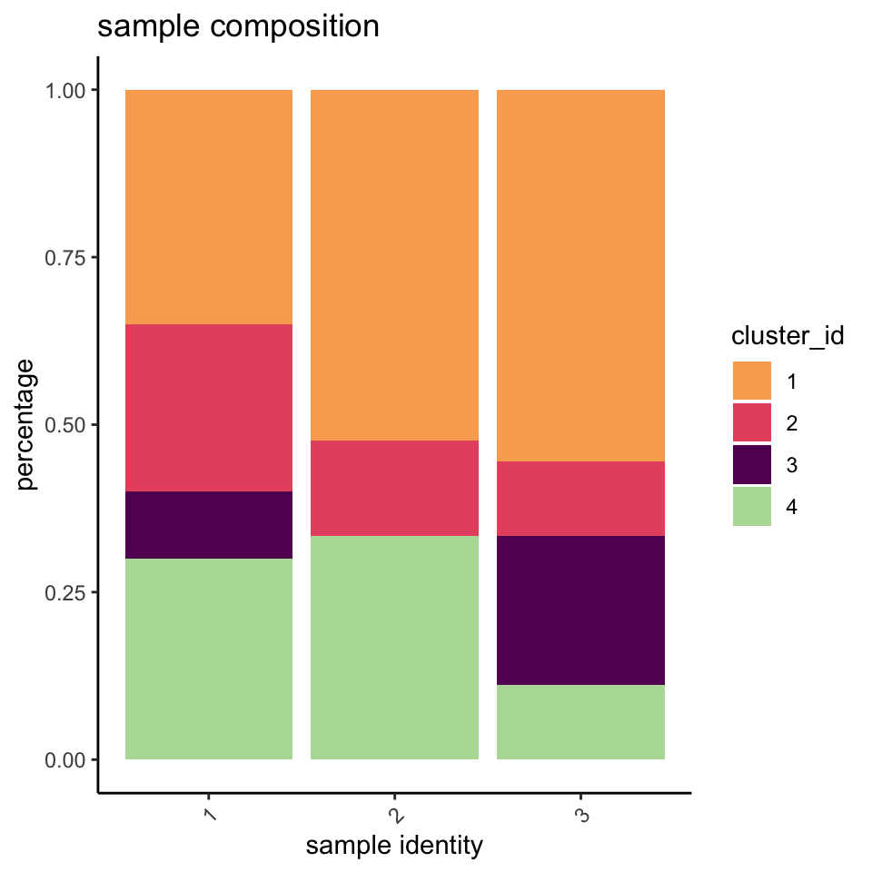

```r
sampleComp(obj, groupBy = "batch", colorBy = "cluster_id", colors = pal)
```

dimFeature is useful for visualizing how different parameters in the cellInfo file are distributed throughout the UMAP:

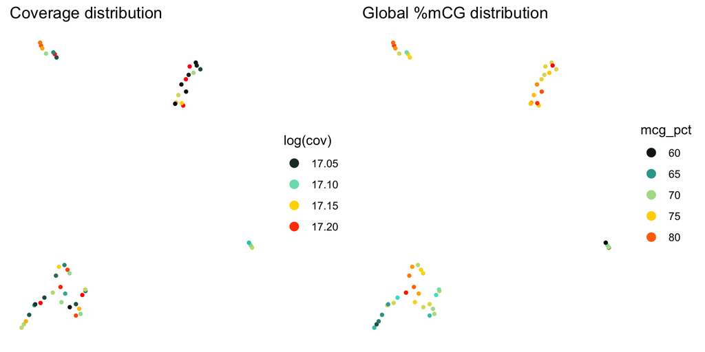

```r
p1 <- dimFeature(obj, colorBy = log(cov), pointSize = 1) + scale_color_gradientn(colors = c("black", "turquoise", "gold", "red")) + ggtitle("Coverage distribution")
p2 <- dimFeature(obj, colorBy = mcg_pct, pointSize = 1) + scale_color_gradientn(colors = c("black", "turquoise", "gold", "red")) + ggtitle("Global %mCG distribution")
plot_grid(p1, p2)
```